# EasyVisa Project

## Data Preprocessing

- Missing value treatment (if needed)
- Feature engineering
- Outlier detection and treatment (if needed)
- Preparing data for modeling
- Any other preprocessing steps (if needed)

```python
# Since the US is looking for workers that can be certified, let's convert "certified" to 1s and "Denied" to 0s.
data["case_status"] = data["case_status"].apply(
    lambda x: 1 if x == "Certified" else 0
)
```

```python
# Convert the case_status field to an int64
data['case_status'] = data['case_status'].astype('int64')
```

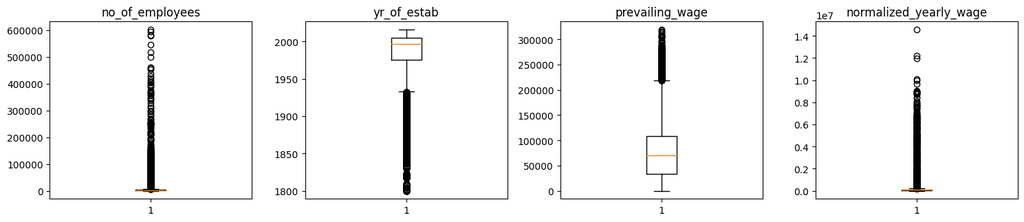

```python
# Let's review the outliers for the numerical fields.
outlier_detection(data)
```

#### Observations

- There are quite a few outliers in the data
- The outliers will not be treated as they are proper values

## EDA

- It is a good idea to explore the data once again after manipulating it.

```python
data.info()
```

```
<class 'pandas.core.frame.DataFrame'>
RangeIndex: 25480 entries, 0 to 25479
Data columns (total 12 columns):
 #   Column                  Non-Null Count  Dtype
---  ------                  --------------  -----
 0   continent               25480 non-null  category
 1   education_of_employee   25480 non-null  category
 2   has_job_experience      25480 non-null  category
 3   requires_job_training   25480 non-null  category
 4   no_of_employees         25480 non-null  int64
 5   yr_of_estab             25480 non-null  int64
 6   region_of_employment    25480 non-null  category
 7   prevailing_wage         25480 non-null  float64
 8   unit_of_wage            25480 non-null  category
 9   full_time_position      25480 non-null  category
 10  case_status             25480 non-null  int64
 11  normalized_yearly_wage  25480 non-null  float64
dtypes: category(7), float64(2), int64(3)
memory usage: 1.1 MB
```

```python
data.describe(include='all').T
```

|  | count | unique | top | freq | mean | std | min | 25% | 50% | 75% | max |
| --- | --- | --- | --- | --- | --- | --- | --- | --- | --- | --- | --- |
| continent | 25480 | 6 | Asia | 16861 | NaN | NaN | NaN | NaN | NaN | NaN | NaN |
| education_of_employee | 25480 | 4 | Bachelor's | 10234 | NaN | NaN | NaN | NaN | NaN | NaN | NaN |
| has_job_experience | 25480 | 2 | Y | 14802 | NaN | NaN | NaN | NaN | NaN | NaN | NaN |
| requires_job_training | 25480 | 2 | N | 22525 | NaN | NaN | NaN | NaN | NaN | NaN | NaN |
| no_of_employees | 25480.000000 | NaN | NaN | NaN | 5667.089207 | 22877.917453 | 11.000000 | 1022.000000 | 2109.000000 | 3504.000000 | 602069.000000 |
| yr_of_estab | 25480.000000 | NaN | NaN | NaN | 1979.409929 | 42.366929 | 1800.000000 | 1976.000000 | 1997.000000 | 2005.000000 | 2016.000000 |
| region_of_employment | 25480 | 5 | Northeast | 7195 | NaN | NaN | NaN | NaN | NaN | NaN | NaN |
| prevailing_wage | 25480.000000 | NaN | NaN | NaN | 74455.814592 | 52815.942327 | 2.136700 | 34015.480000 | 70308.210000 | 107735.512500 | 319210.270000 |
| unit_of_wage | 25480 | 4 | Year | 22962 | NaN | NaN | NaN | NaN | NaN | NaN | NaN |
| full_time_position | 25480 | 2 | Y | 22773 | NaN | NaN | NaN | NaN | NaN | NaN | NaN |
| case_status | 25480.000000 | NaN | NaN | NaN | 0.667896 | 0.470977 | 0.000000 | 0.000000 | 1.000000 | 1.000000 | 1.000000 |
| normalized_yearly_wage | 25480.000000 | NaN | NaN | NaN | 197391.155259 | 578591.666314 | 100.000000 | 47107.965000 | 82839.460000 | 124825.035000 | 14569149.400000 |

#### Observation

- The data is still in good shape.

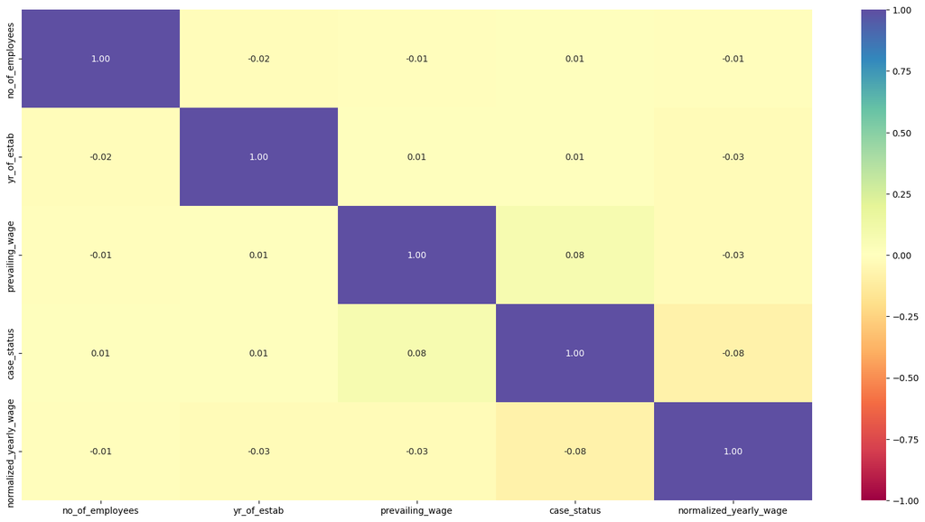

```python
# Create heatmap to help identify any correlations between numberic fields.
plt.figure(figsize=(20,10))
sns.heatmap(data.corr(),annot=True,vmin=-1,vmax=1,fmt='.2f',cmap="Spectral")
plt.show()
```

#### Observations

- There are no correlations between the numeric fields.
- The correlations seem very low.